# Introduction to R (part III)

Paula Lissón  
November 2021

Universität Potsdam  
Deparment of Linguistics

Contact : paula.lisson@uni-potsdam.de

### First things first: QUESTIONS?

- Is there anything from the previous presentation or from the homework that you don't understand?

Today we will talk about:

- tapply and xtabs
- Importing and exporting tabular data
- User-defined functions
- Plotting, histograms, scatter plots (maybe)

### Tapply function

tapply() computes mean, median, min, max… values for each factor variable in a vector (or column, in dataframes). See:

```r
data(iris)
tapply(iris$Sepal.Length, iris$Species, mean)
```

```
    setosa versicolor  virginica
     5.006      5.936      6.588
```

```r
tapply(iris$Sepal.Length, iris$Species, sd)
```

```
    setosa versicolor  virginica
 0.3524897  0.5161711  0.6358796
```

### Tapply function

Another syntax to achieve the same goal:

```r
with(iris, tapply(Sepal.Length, IND=Species, mean))
```

```
    setosa versicolor  virginica
     5.006      5.936      6.588
```

Compare with:

```r
tapply(iris$Sepal.Length, iris$Species, mean)
```

```
    setosa versicolor  virginica
     5.006      5.936      6.588
```

### xtabs function

It allows you to create cross-tabulate data, useful for factors. See:

```r
iris$color <- c(rep("red",50),rep("blue",50), rep("yellow",50))
xtabs(~color+Species,data=iris)
```

```
        Species
color    setosa versicolor virginica
  blue        0         50         0
  red        50          0         0
  yellow      0          0        50
```

Sometimes it's useful to combine it with the transpose function **t()** depending on your preferences, see:

```r
t(xtabs(~color+Species,data=iris))
```

```
            color
Species      blue red yellow
  setosa        0  50      0
  versicolor   50   0      0
  virginica     0   0     50
```

### Importing and exporting tabular data

As you have seen, the data frame in R is similar to the classical spreadsheet. We can easily load spreadsheets with our data in R:

```r
mydata <- read.table("myspreadsheet.txt",header=T)
mydata <- read.table("myspreadsheet.csv",header=T)
```

Notice the file format (txt/csv). After the analysis of the data with R, we can export data with:

```r
write.table(nameofthedataframe, file = "myfile.csv")
```

### Working directory

The file has to be in the proper working directory so that R can read it, and R will output the file with the command write.table() to the working directory. Otherwise, we have to specify the path of the files.

### Working directory

You can get your current working directory by using this command:

```r
getwd()
```

```
[1] "/Users/paula/Dropbox/Teaching/IntroR2021/slides"
```

You can set up the path to a working directory (careful! not the same for Mac and Windows users):

```r
setwd("~/Dropbox/Teaching/IntroR2021")
```

Or, manually in R by clicking on:

Session > Working directory > Choose directory

### User-written (or used-defined) functions

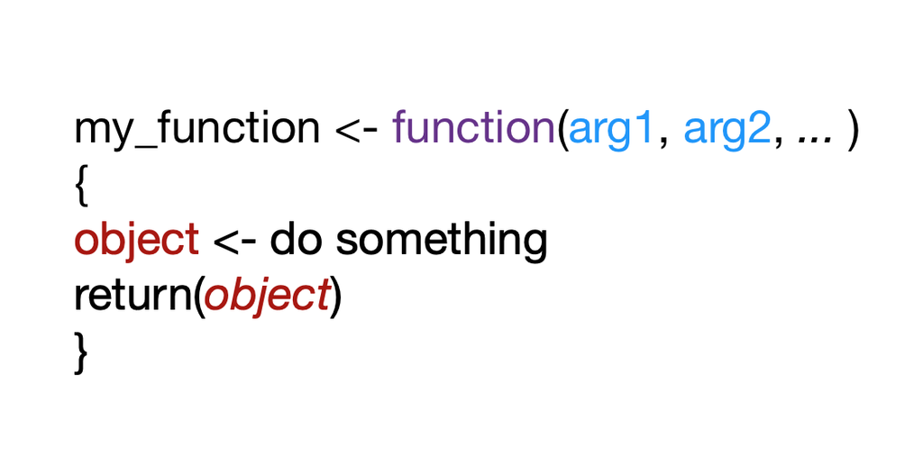

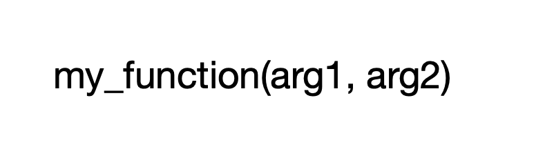

### User-written (or used-defined) functions

Take, for example, the for loop that we did before:

```r
sample.means <- rep(NA,1000)
for(i in 1:1000){
sample.40 <- rnorm(40,mean=60,sd=4)
sample.means[i] <- mean(sample.40)
}
```

We could create a function:

```r
sampling_function <- function(Nsamples,N,mean,sd){
  sample.means <- rep(NA,Nsamples)
  for(i in 1:Nsamples){
      sample <- rnorm(N,mean=mean,
                      sd=sd)
      sample.means[i] <- mean(sample)
  }
  return(sample.means)}
```

### User-written (or used-defined) functions

We have created our function! Now we can use it. We need to call the function and to fill its arguments. For example:

```r
myresult <- sampling_function(Nsamples=200,N=20,mean=10,sd=3)
length(myresult)
```

```
[1] 200
```

```r
#we can also write arguments directly:
myresult2 <- sampling_function(100,100,2,5)
length(myresult2)
```

```
[1] 100
```

Be careful where you place things! Look at what happens if I define the sample.means vector inside the for loop:

```r
sampling_function_wrong <- function(Nsamples,N,mean,sd){
  for(i in 1:Nsamples){
    sample.means <- rep(NA,Nsamples)
      sample <- rnorm(N,mean=mean,
                      sd=sd)
      sample.means[i] <- mean(sample)
  }
  return(sample.means)
}

myresult_wrong <- sampling_function_wrong(200,N=20,mean=10,sd=3)
head(myresult_wrong)
```

```
[1] NA NA NA NA NA NA
```

Why am I getting this?

(Nsamples= **200**, N=**20**, mean=10, sd=3)

```r
sampling_function_wrong <- function(Nsamples,N,mean,sd){
  for(i in 1:Nsamples){ # for i in 1:200
    # rep NA 200 times
    sample.means <- rep(NA,Nsamples)
    #sample 20 datapoints
    sample <- rnorm(N,mean=mean,
                      sd=sd)
    sample.means[i] <- mean(sample)
  }
  return(sample.means)
}
```

- The problem is that we included the command “sample.means <- rep(NA,Nsamples)” inside the for loop. So we are not creating a single dataset to store our means, we are creating 200 datasets, one for each iteration of the for loop.
- We are creating one dataset of 200 empty slots 200 times, and in every iteration of the for loop we can only fill one of the empty slots.
- So what we get at the end is one of these datasets (the last one), that has 1 mean, and 199 empty (NA) slots.

Compare with the original function:

(Nsamples= **200**, N=**20**, mean=10, sd=3)

```r
sampling_function <- function(Nsamples,N,mean,sd){
  # create a vector of NA of size 200
  sample.means <- rep(NA,Nsamples)
  # for each element in 1:200
  for(i in 1:Nsamples){
      # sample 20 datapoints
      sample <- rnorm(N,mean=mean,
                      sd=sd)
      sample.means[i] <- mean(sample)
      # take the mean of these 20 datapoints
      #and store it in my vector of size 200
  }
  return(sample.means)}
  # return my vector of size 200
  #filled with the means
```

### Plotting: Histograms

- A histogram is simply a way to graphically explore the distribution of a numerical vairable

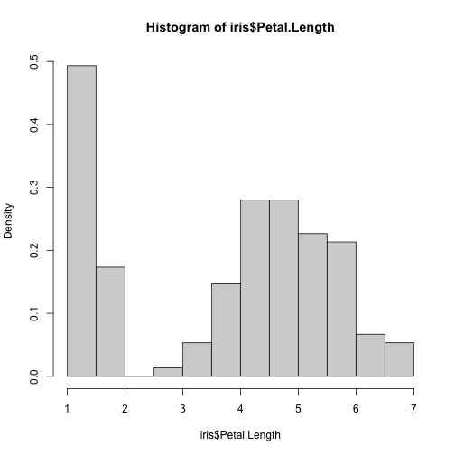

```r
hist(iris$Petal.Length,freq=F)
```

### Plotting: Histograms

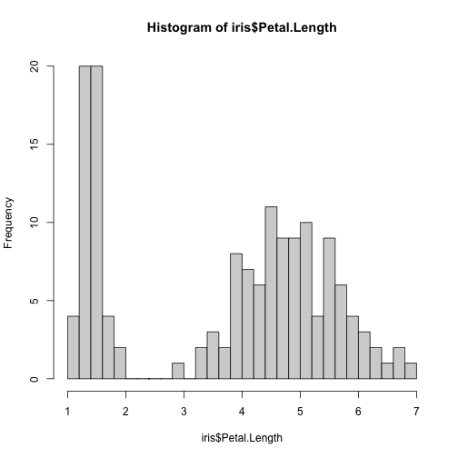

```r
hist(iris$Petal.Length,breaks=30)
```

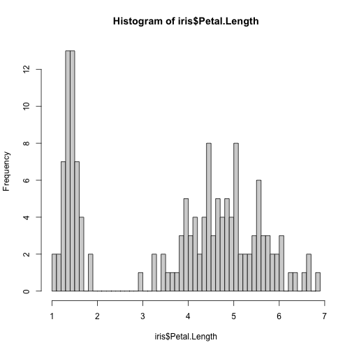

```r
hist(iris$Petal.Length,breaks=50)
```

### Plotting: Scatter plots

An way to observe the relationship between two numeric variables:

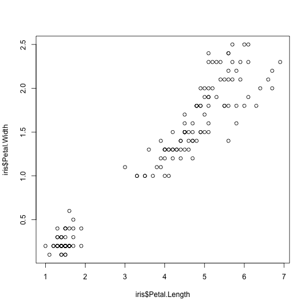

```r
plot(iris$Petal.Length, iris$Petal.Width)
```

Given the scatter plot in the previous slide, what can we observe about the relationship between Petal Lenght and Petal Width?

- This can be also checked numerically:

```r
cor(iris$Petal.Length, iris$Petal.Width)
```

```
[1] 0.9628654
```